# DL_PART_10

The Horses and Humans dataset is commonly used for learning CNNs because it involves classifying complex real-world images, unlike simpler datasets like Fashion MNIST. This dataset contains color images of horses and humans in various poses, making it a great choice for understanding CNN concepts such as feature extraction, convolutions, and pooling in a more realistic setting.

Compared to Fashion MNIST, which consists of grayscale, low-resolution images of clothing items (shoes, shirts, etc.), the Horses and Humans dataset presents more challenges. It includes variations in lighting, background noise, and object orientation, which makes CNNs work harder to extract meaningful features. This helps learners understand how convolutional layers detect edges, textures, and complex patterns, which is closer to real-world applications like medical imaging or object detection.

Moreover, Fashion MNIST has structured and well-separated categories, making classification easier. However, distinguishing between a horse and a human involves more fine-grained features, making it a better dataset for understanding CNNs in practical scenarios.

Thus, working with Horses and Humans helps learners gain deeper insights into how CNNs handle real-world images, improving their ability to train models beyond simple datasets like Fashion MNIST.

#### **Importing all the necessary libraries**

```python
import os
import random
import numpy as np
import tensorflow as tf

import matplotlib.pyplot as plt
import matplotlib.image as mpimg
```

#### **Fetching data from directory**

Creating subdirectories within a base directory helps in organizing data efficiently, especially for image classification tasks. By structuring data into labeled folders (e.g., /train/horses/, /train/humans/, /validation/horses/, /validation/humans/), deep learning frameworks like TensorFlow can automatically load and label images using functions like image_dataset_from_directory(). This approach makes data preprocessing easier, ensures a clear separation between training and validation sets, and enables efficient batch loading and augmentation (which we will see later). It also improves code maintainability by keeping datasets structured, allowing for better scalability and automation in model training.

```python
TRAIN_DIR = 'horse-or-human'  # Base folder which has the images
VALIDATION_DIR = 'validation-horse-or-human'

print('Files in current directory : ', os.listdir())
print(f'Subfolders within {TRAIN_DIR} are : {os.listdir(TRAIN_DIR)}')
```

```
Files in current directory :  ['.ipynb_checkpoints', 'DL_PART_1.ipynb', 'DL_PART_2.ipynb', 'DL_PART_3.ipynb', 'DL_PART_4.ipynb', 'horse-or-human', 'validation-horse-or-human']
Subfolders within horse-or-human are : ['horses', 'humans']
```

```python
TRAIN_HORSE_DIR = os.path.join(TRAIN_DIR, 'horses')
TRAIN_HUMAN_DIR = os.path.join(TRAIN_DIR, 'humans')
VAL_HORSE_DIR = os.path.join(VALIDATION_DIR, 'horses')
VAL_HUMAN_DIR = os.path.join(VALIDATION_DIR, 'humans')

train_horse_names = os.listdir(TRAIN_HORSE_DIR)
train_human_names = os.listdir(TRAIN_HUMAN_DIR)
val_horse_names = os.listdir(VAL_HORSE_DIR)
val_human_names = os.listdir(VAL_HUMAN_DIR)

print('5 files from Horse directory : ', train_horse_names[:5])
print('5 files from Human directory : ', train_human_names[:5])
```

```
5 files from Horse directory :  ['horse01-0.png', 'horse01-1.png', 'horse01-2.png', 'horse01-3.png', 'horse01-4.png']
5 files from Human directory :  ['human01-00.png', 'human01-01.png', 'human01-02.png', 'human01-03.png', 'human01-04.png']
```

```python
print('Total number of images in Horse category : ', len(train_horse_names))
print('Total number of images in Human category : ', len(train_human_names))

print('Total number of images in Horse category in Validation : ', len(val_horse_names))
print('Total number of images in Human category in Validation : ', len(val_human_names))
```

```
Total number of images in Horse category :  500
Total number of images in Human category :  527
Total number of images in Horse category in Validation :  128
Total number of images in Human category in Validation :  128
```

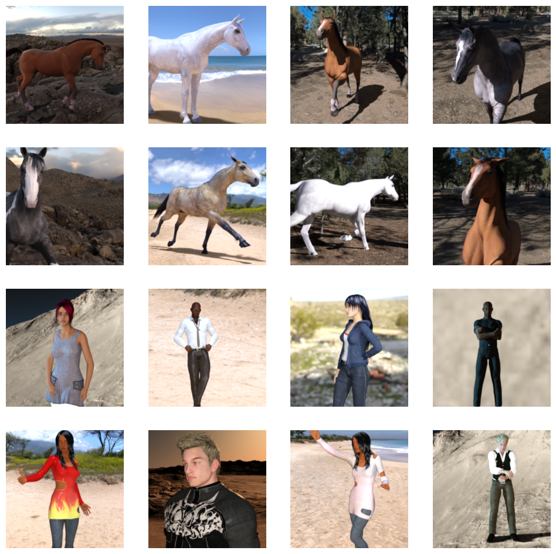

```python
# Let's vizualize few random images
# To output images in 4 by 4 configuration
nrows = 4
ncols = 4

fig = plt.gcf()
fig.set_size_inches(ncols * 3, nrows * 3)

next_horse_pic = [os.path.join(TRAIN_HORSE_DIR, fname) for fname in random.sample(train_horse_names, k=8)]
next_human_pic = [os.path.join(TRAIN_HUMAN_DIR, fname) for fname in random.sample(train_human_names, k=8)]

for i, img_path in enumerate(next_horse_pic + next_human_pic):
    sp = plt.subplot(nrows, ncols, i+1)
    sp.axis('off')
    img = mpimg.imread(img_path)
    plt.imshow(img)

plt.show()
```

#### **Building a small model from scratch**

```python
# Building a CNN model using multiple Convolution and Maxpooling layers to better understand features

model = tf.keras.models.Sequential([
    tf.keras.Input(shape=(300,300,3)),
    tf.keras.layers.Conv2D(16, (3,3), activation='relu'),
    tf.keras.layers.MaxPooling2D(2,2),
    tf.keras.layers.Conv2D(32, (3,3), activation='relu'),
    tf.keras.layers.MaxPooling2D(2,2),
    tf.keras.layers.Conv2D(64, (3,3), activation='relu'),
    tf.keras.layers.MaxPooling2D(2,2),
    tf.keras.layers.Conv2D(64, (3,3), activation='relu'),
    tf.keras.layers.MaxPooling2D(2,2),
    tf.keras.layers.Conv2D(64, (3,3), activation='relu'),
    tf.keras.layers.MaxPooling2D(2,2),
    tf.keras.layers.Flatten(),
    tf.keras.layers.Dense(512, activation='relu'),
    tf.keras.layers.Dense(1, activation='sigmoid')
])

model.summary()
```

```
Model: "sequential"
```

```
┏━━━━━━━━━━━━━━━━━━━━━━━━━━━━━━━━━━━━━━┳━━━━━━━━━━━━━━━━━━━━━━━━━━━━━┳━━━━━━━━━━━━━━━━━┓
┃ Layer (type)                         ┃ Output Shape                ┃         Param # ┃
┡━━━━━━━━━━━━━━━━━━━━━━━━━━━━━━━━━━━━━━╇━━━━━━━━━━━━━━━━━━━━━━━━━━━━━╇━━━━━━━━━━━━━━━━━┩
│ conv2d (Conv2D)                      │ (None, 298, 298, 16)        │             448 │
├──────────────────────────────────────┼─────────────────────────────┼─────────────────┤
│ max_pooling2d (MaxPooling2D)         │ (None, 149, 149, 16)        │               0 │
├──────────────────────────────────────┼─────────────────────────────┼─────────────────┤
│ conv2d_1 (Conv2D)                    │ (None, 147, 147, 32)        │           4,640 │
├──────────────────────────────────────┼─────────────────────────────┼─────────────────┤
│ max_pooling2d_1 (MaxPooling2D)       │ (None, 73, 73, 32)          │               0 │
├──────────────────────────────────────┼─────────────────────────────┼─────────────────┤
│ conv2d_2 (Conv2D)                    │ (None, 71, 71, 64)          │          18,496 │
├──────────────────────────────────────┼─────────────────────────────┼─────────────────┤
│ max_pooling2d_2 (MaxPooling2D)       │ (None, 35, 35, 64)          │               0 │
├──────────────────────────────────────┼─────────────────────────────┼─────────────────┤
│ conv2d_3 (Conv2D)                    │ (None, 33, 33, 64)          │          36,928 │
├──────────────────────────────────────┼─────────────────────────────┼─────────────────┤
│ max_pooling2d_3 (MaxPooling2D)       │ (None, 16, 16, 64)          │               0 │
├──────────────────────────────────────┼─────────────────────────────┼─────────────────┤
│ conv2d_4 (Conv2D)                    │ (None, 14, 14, 64)          │          36,928 │
├──────────────────────────────────────┼─────────────────────────────┼─────────────────┤
│ max_pooling2d_4 (MaxPooling2D)       │ (None, 7, 7, 64)            │               0 │
├──────────────────────────────────────┼─────────────────────────────┼─────────────────┤
│ flatten (Flatten)                    │ (None, 3136)                │               0 │
├──────────────────────────────────────┼─────────────────────────────┼─────────────────┤
│ dense (Dense)                        │ (None, 512)                 │       1,606,144 │
├──────────────────────────────────────┼─────────────────────────────┼─────────────────┤
│ dense_1 (Dense)                      │ (None, 1)                   │             513 │
└──────────────────────────────────────┴─────────────────────────────┴─────────────────┘
```

```
 Total params: 1,704,097 (6.50 MB)
```

```
 Trainable params: 1,704,097 (6.50 MB)
```

```
 Non-trainable params: 0 (0.00 B)
```

```python
model.compile(optimizer=tf.keras.optimizers.RMSprop(learning_rate=0.001),
              loss = 'binary_crossentropy',
              metrics=['accuracy'])
```

The above code compiles a CNN model with the following settings:

- Optimizer: RMSprop(learning_rate=0.001) – Helps adjust weights efficiently using adaptive learning rates.
- Loss Function: 'binary_crossentropy' – Used for binary classification tasks (e.g., classifying images into two categories like Horses vs. Humans).
- Metrics: ['accuracy'] – Tracks the model’s performance by measuring the percentage of correct predictions.

#### **Preprocessing the dataset before fitting the model with it**

The below code loads images from directories and prepares them for training and validation in a CNN model.

- image_dataset_from_directory() automatically loads, labels, and batches images from the given directories (TRAIN_DIR and VALIDATION_DIR).
- image_size=(300,300) resizes all images to 300x300 pixels for consistency.
- batch_size=32 processes images in groups of 32 for efficient training.
- label_mode='binary' assigns labels as 0 or 1, making it suitable for binary classification tasks (e.g., Horses vs. Humans).

```python
train_dataset = tf.keras.utils.image_dataset_from_directory(
    TRAIN_DIR,
    image_size=(300,300),
    batch_size=32,
    label_mode='binary'
)

validation_dataset = tf.keras.utils.image_dataset_from_directory(
    VALIDATION_DIR,
    image_size=(300,300),
    batch_size=32,
    label_mode='binary'
)

dataset_type = type(train_dataset)
print('Train dataset inherits from tf.data.Dataset : ', issubclass(dataset_type, tf.data.Dataset))
```

```
Found 1027 files belonging to 2 classes.
Found 256 files belonging to 2 classes.
Train dataset inherits from tf.data.Dataset :  True
```

```python
# Get one batch from the dataset to take a look at the shape and structure of the image

# Takes one batch of images and labels from train_dataset
sample_batch = list(train_dataset.take(1))[0]

print('Type of sample batch : ', type(sample_batch))
print('Number of elements in the batch ; ', len(sample_batch))


# image_batch contains image tensors, and label_batch contains corresponding binary labels
image_batch = sample_batch[0]
label_batch = sample_batch[1]

print('Image batch shape : ', image_batch.shape)
print('Sample batch shape : ', label_batch.shape)
print('Maximum and Minimum Values from batch - ',np.max(image_batch[0].numpy()), np.min(image_batch[0].numpy()))
```

```
Type of sample batch :  <class 'tuple'>
Number of elements in the batch ;  2
Image batch shape :  (32, 300, 300, 3)
Sample batch shape :  (32, 1)
Maximum and Minimum Values from batch -  255.0 1.0
```

```python
len(image_batch), len(image_batch[0]), len(image_batch[0][0]), len(image_batch[0][0][0])
```

```
(32, 300, 300, 3)
```

Above code returns the shape details of an image batch:

- Batch size
- Image height
- Image width
- Number of channels (3 for RGB images)

Below code creates a Rescaling layer to normalize pixel values from [0,255] → [0,1] for better training stability.

```python
# tensorflow has layer for rescaling the way we were doing standardization
rescale_layer = tf.keras.layers.Rescaling(scale=1.0/255.0)

# performing it on one image
image_scaled = rescale_layer(image_batch[0]).numpy()
print('Maximum and Minimum value after rescale ', np.max(image_scaled), np.min(image_scaled))
```

```
Maximum and Minimum value after rescale  1.0 0.003921569
```

```python
# Useing .map() to apply rescaling to each image in train_dataset and validation_dataset
# Ensures all images are normalized before training the model

train_dataset_rescaled = train_dataset.map(lambda image, label : (rescale_layer(image), label))
validation_dataset_rescaled = validation_dataset.map(lambda img, label : (rescale_layer(img), label))
```

```python
# Let's pick a random batch and check pixel values

sample_batch = list(train_dataset_rescaled.take(1))[0]
image_scaled = sample_batch[0][1].numpy()

np.max(image_scaled), np.min(image_scaled)
```

```
(1.0, 0.015686275)
```

Explanation of the below code -

- SHUFFLE_BUFFER_SIZE = 1000
  - Defines the buffer size for shuffling data.
  - A larger value ensures better randomness in the dataset, helping the model generalize better.
  - Here, 1000 means that the dataset maintains a buffer of 1000 samples before selecting a random batch.
- PREFETCH_BUFFER_SIZE = tf.data.AUTOTUNE
  - Optimizes dataset loading by prefetching batches during training.
  - tf.data.AUTOTUNE dynamically adjusts the prefetch size for better performance.
  - Loads data in advance while the model is training, reducing bottlenecks.
- .cache(): Stores the dataset in memory for faster access.

```python
# Using .cache() and .prefetch() for efficient batch loading.

SHUFFLE_BUFFER_SIZE = 1000
PREFETCH_BUFFER_SIZE = tf.data.AUTOTUNE

train_dataset_final = (train_dataset_rescaled
                       .cache()
                       .shuffle(SHUFFLE_BUFFER_SIZE)
                       .prefetch(PREFETCH_BUFFER_SIZE))

# No .shuffle() because validation data should remain in the same order.
validation_dataset_final = (validation_dataset_rescaled
                            .cache()
                            .prefetch(PREFETCH_BUFFER_SIZE))
```

#### Training and evaluating the model

```python
# MODEL TRAINING

history = model.fit(train_dataset_final, validation_data=validation_dataset_final, epochs=15, verbose=2)
```

```
33/33 - 8s - 250ms/step - accuracy: 0.7313 - loss: 0.5762 - val_accuracy: 0.9062 - val_loss: 0.2669
33/33 - 8s - 242ms/step - accuracy: 0.8569 - loss: 0.3593 - val_accuracy: 0.8789 - val_loss: 0.3573
33/33 - 8s - 241ms/step - accuracy: 0.9172 - loss: 0.2294 - val_accuracy: 0.5000 - val_loss: 2.6558
33/33 - 8s - 240ms/step - accuracy: 0.9007 - loss: 0.2931 - val_accuracy: 0.8789 - val_loss: 0.5835
33/33 - 8s - 241ms/step - accuracy: 0.9270 - loss: 0.3946 - val_accuracy: 0.8750 - val_loss: 0.9056
33/33 - 8s - 240ms/step - accuracy: 0.9591 - loss: 0.1068 - val_accuracy: 0.8984 - val_loss: 0.5385
33/33 - 8s - 242ms/step - accuracy: 0.9766 - loss: 0.0720 - val_accuracy: 0.8555 - val_loss: 1.4865
33/33 - 8s - 238ms/step - accuracy: 0.9912 - loss: 0.0401 - val_accuracy: 0.8828 - val_loss: 1.1572
33/33 - 8s - 238ms/step - accuracy: 0.9815 - loss: 0.0672 - val_accuracy: 0.8672 - val_loss: 1.1994
33/33 - 8s - 240ms/step - accuracy: 0.9893 - loss: 0.0256 - val_accuracy: 0.8125 - val_loss: 2.3226
33/33 - 8s - 246ms/step - accuracy: 0.9864 - loss: 0.0356 - val_accuracy: 0.8945 - val_loss: 1.5839
33/33 - 8s - 241ms/step - accuracy: 0.9659 - loss: 0.3245 - val_accuracy: 0.8828 - val_loss: 1.6553
33/33 - 8s - 237ms/step - accuracy: 1.0000 - loss: 0.0027 - val_accuracy: 0.8867 - val_loss: 1.4892
33/33 - 8s - 240ms/step - accuracy: 1.0000 - loss: 4.5246e-04 - val_accuracy: 0.8867 - val_loss: 1.8155
33/33 - 8s - 240ms/step - accuracy: 1.0000 - loss: 1.0632e-04 - val_accuracy: 0.8828 - val_loss: 2.2495
```

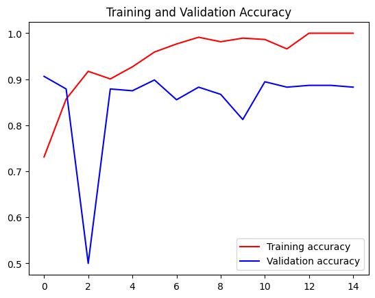

```python
# Plotting the training accuracy

acc = history.history['accuracy']
val_acc = history.history['val_accuracy']
loss = history.history['loss']
val_loss = history.history['val_loss']
epochs = range(len(acc))

plt.plot(epochs, acc, 'r', label = 'Training accuracy')
plt.plot(epochs, val_acc, 'b', label = 'Validation accuracy')
plt.title('Training and Validation Accuracy')
plt.legend(loc=0)
plt.show()
```

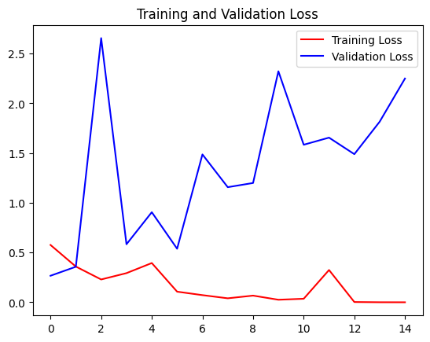

```python
plt.plot(epochs, loss, 'r', label = 'Training Loss')
plt.plot(epochs, val_loss, 'b', label = 'Validation Loss')
plt.title('Training and Validation Loss')
plt.legend(loc=0)
plt.show()
```

#### Prediction

```python
# predicting a single image

file = os.path.join(VAL_HUMAN_DIR, val_human_names[100])
image = tf.keras.utils.load_img(file, target_size=(300,300))
image = tf.keras.utils.img_to_array(image)
image = rescale_layer(image)
image = np.expand_dims(image, axis = 0)
image.shape
```

```
(1, 300, 300, 3)
```

```python
prediction = model.predict(image, verbose=False)[0][0]
if prediction > 0.5:
    print('Human')
else:
    print('Horse')
```

```
Human
```

```python
# Let's predict on the complete dataset

prediction = model.predict(validation_dataset_final, verbose=False)
labels = np.concatenate([label_batch.numpy() for _, label_batch in validation_dataset_final])
labels = [int(lab) for label in labels for lab in label]
prediction = [1 if x[0] > 0.5 else 0 for x in prediction]
```

```python
from collections import Counter

Counter(prediction)
```

```
Counter({1: 152, 0: 104})
```

```python
Counter(labels)
```

```
Counter({1: 128, 0: 128})
```

#### **Let's visualize the features that CNN has learned**

```python
#This extracts the outputs of all layers in the model starting from the second layer ([1:]).
#It skips the input layer and captures outputs of the following layers, which will be used for visualization.
successive_outputs = [layer.output for layer in model.layers[1:]]


# Creates a new model called vizualization_model where:
#The input is the same as the original model’s input.
#The outputs are the feature maps from the layers (starting from the second layer) of the original model.
vizualization_model = tf.keras.models.Model(inputs = model.inputs, outputs = successive_outputs)



#Generates file paths for images of horses and humans by combining directory paths (TRAIN_HORSE_DIR, TRAIN_HUMAN_DIR)
#with filenames (train_horse_names, train_human_names).
horse_image_file = [os.path.join(TRAIN_HORSE_DIR, f) for f in train_horse_names]
human_image_file = [os.path.join(TRAIN_HUMAN_DIR, f) for f in train_human_names]

# Randomly selects an image from either the horse or human images to be visualized.
img_path = random.choice(horse_image_file + human_image_file)


# Loads the image from the randomly selected path (img_path) and resizes it to 300x300 pixels.
img = tf.keras.utils.load_img(img_path, target_size=(300,300))


# Converts the image into a NumPy array and reshapes it to (1, 300, 300, 3) to match the input shape required by the model.
x = tf.keras.utils.img_to_array(img)
x = x.reshape((1,) + x.shape)

# Applies rescaling (dividing pixel values by 255) using the previously defined rescale_layer to normalize the image for the model.
x = rescale_layer(x)


#Passes the image (x) through the visualization model to get the activations (feature maps) from all layers (except the input layer).
successive_feature_maps = vizualization_model.predict(x, verbose=False)


# Retrieves the names of the layers (except the input layer) to label the visualizations.
layer_names = [layer.name for layer in model.layers[1:]]
```

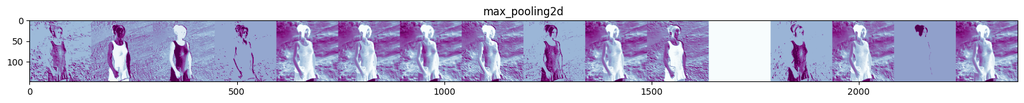

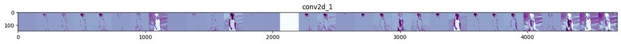

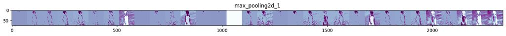

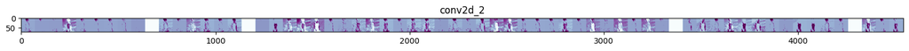

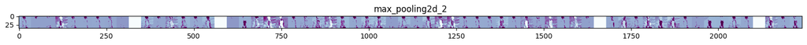

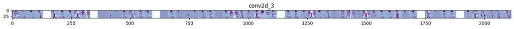

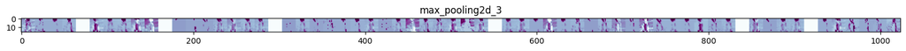

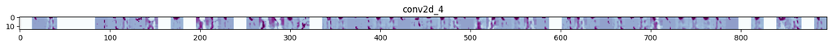

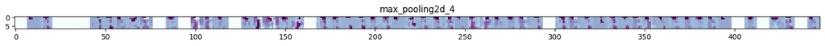

```python
# Iterates through each layer’s name and its corresponding feature map.
for layer_name, feature_map in zip(layer_names, successive_feature_maps):

    # Checks if the feature map is a 4D array, which typically represents convolutional layers' outputs (batch size, height, width, number of features)
    if len(feature_map.shape) == 4:

        # n_features is the number of filters (feature channels) in the layer, and size is the height/width of the feature map.
        n_features = feature_map.shape[-1]
        size = feature_map.shape[1]

        # Creates an empty grid to display the feature maps. The grid width is n_features * size to accommodate all features.
        display_grid = np.zeros((size, size*n_features))


        # Normalizes and adjusts each feature map channel:
                #Centers and scales each feature map to have a mean of 0 and a standard deviation of 1.
                #Multiplies by 64 and adds 128 to adjust the contrast and brightness.
                #Clips the values to be between 0 and 255, ensuring valid pixel values.
                #Fills the grid with the processed feature maps for visualization.
        for i in range(n_features):
            x=feature_map[0, :, :, i]
            x-=x.mean()
            x /= x.std()
            x *= 64
            x += 128
            x = np.clip(x, 0, 255).astype('uint8')
            display_grid[:, i*size : (i+1) * size] = x


        #Adjusts the figure size based on the number of features.
        scale = 20./n_features
        plt.figure(figsize=(scale*n_features, scale))
        plt.title(layer_name)
        plt.grid(False)
        plt.imshow(display_grid, aspect='auto', cmap='BuPu')
```